# hyperparameter-tuning

# Lab 8 - HyperParameter Tuning

## Data import/tidy/transform

```r
#libraries
library(tidyverse)
library(tidymodels)
library(powerjoin)
library(glue)
library(vip)
library(baguette)
library(ggplot2)
library(patchwork)
library(xgboost)
library(skimr)
library(visdat)
#data ingest
#root
root  <- 'https://gdex.ucar.edu/dataset/camels/file'
#documentation pdf
download.file('https://gdex.ucar.edu/dataset/camels/file/camels_attributes_v2.0.pdf',
              'data/camels_attributes_v2.0.pdf')
#get basin characteristics
types <- c("clim", "geol", "soil", "topo", "vege", "hydro")
# Where the files live online ...
remote_files  <- glue('{root}/camels_{types}.txt')
# where we want to download the data ...
local_files   <- glue('data/camels_{types}.txt')

walk2(remote_files, local_files, download.file, quiet = TRUE)

#read/merge data
# Read and merge data
camels <- map(local_files, read_delim, show_col_types = FALSE)

#join all the dataframes (n=6)
camels_raw <- power_full_join(camels ,by = 'gauge_id')

#data cleaning
camels <- camels_raw %>%
  mutate(
    elev_mean = as.numeric(elev_mean),
    slope_mean = as.numeric(slope_mean))

skim_summary <- skim(camels)
print(skim_summary)
```

```
── Data Summary ────────────────────────
                           Values
Name                       camels
Number of rows             671
Number of columns          58
_______________________
Column type frequency:
  character                6
  numeric                  52
________________________
Group variables            None

── Variable type: character ────────────────────────────────────────────────────
  skim_variable    n_missing complete_rate min max empty n_unique whitespace
1 gauge_id                 0         1       8   8     0      671          0
```

[output cut: 113 more lines]

```r
vis_missingdata <- vis_miss(camels)
```

## Data splitting

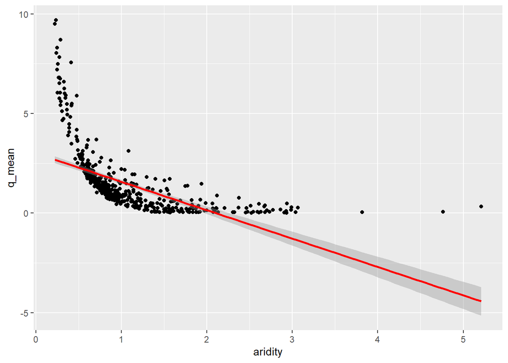

```r
#start
set.seed(123)

#log transform Qmean
camels <- camels |>
  mutate(logQmean = log(q_mean))

# test/training split
camels_split <- initial_split(camels, prop = 0.8)
camels_train <- training(camels_split)
camels_test  <- testing(camels_split)

#feature engineering

#q_mean vs. aridity
ggplot(camels_train, aes(x = aridity, y = q_mean)) +
  geom_point() +
  geom_smooth(method = "lm", color = "red")
```

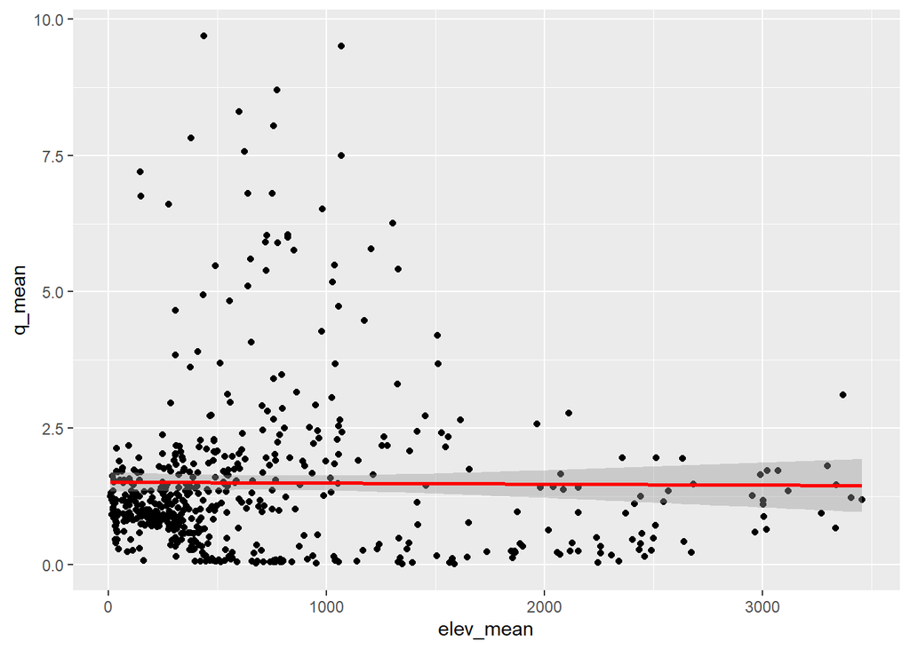

```r
#q_mean vs. elev_mean
ggplot(camels_train, aes(x = elev_mean, y = q_mean)) +
  geom_point() +
  geom_smooth(method = "lm", color = "red")
```

```r
# Create recipe
rec <-  recipe(logQmean ~ aridity + elev_mean, data = camels_train) %>%
  step_log(all_predictors()) %>%
  step_interact(terms = ~ aridity:elev_mean) |>
  step_naomit(all_predictors(), all_outcomes())

# Prep data
baked_data <- prep(rec, camels_train) |>
  bake(new_data = NULL)
```

## Data Resampling and Model Testing

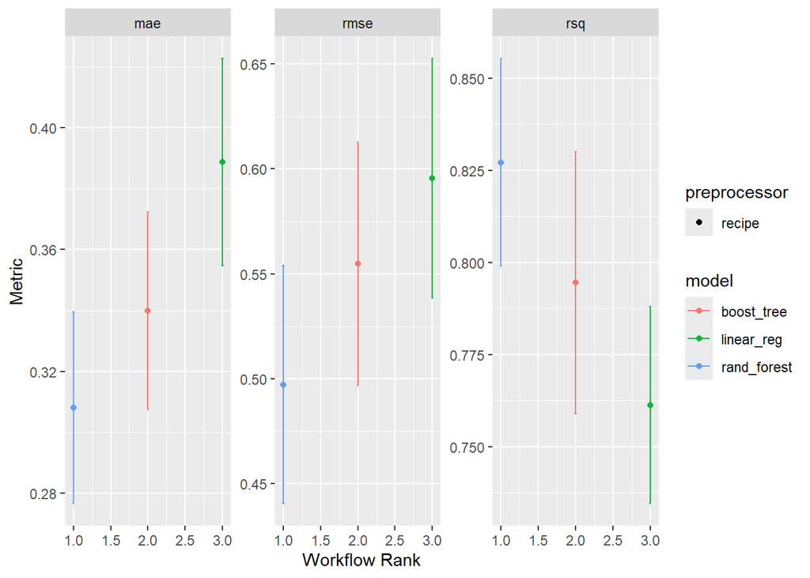

```r
#cross validation Dataset (k-folds)
folds <- vfold_cv(camels_train, v = 10)

#Define 3 regression models

#1- Linear Model
lm_model <- linear_reg() %>%
  # define the engine
  set_engine("lm") %>%
  # define the mode
  set_mode("regression")

#2- Linear ModelRand Forest
RF_model <- rand_forest() %>%
  # define the engine
  set_engine("ranger") %>%
  # define the mode
  set_mode("regression")

#3- Boosted Tree
xgb_model <- boost_tree() %>%
  # define the engine
  set_engine("xgboost") %>%
  # define the mode
  set_mode("regression")

#Workflow Setup/Map/Autoplot
#models
# Create workflows for each model
lm_workflow <- workflow() %>%
  add_recipe(rec) %>%
  add_model(lm_model)

rf_workflow <- workflow() %>%
  add_recipe(rec) %>%
  add_model(RF_model)

xgb_workflow <- workflow() %>%
  add_recipe(rec) %>%
  add_model(xgb_model)

# Combine workflows into a workflow set
base_workflows <- workflow_set(
  preproc = list(simple = rec),
   models = list(
    linear_reg = lm_model,
    random_forest = RF_model,
    xgboost = xgb_model
  )
)

# Test the models using workflow_map()
model_metrics <- base_workflows %>%
  workflow_map(
    resamples = folds,
    metrics = metric_set(rmse, rsq, mae))
#results
autoplot(model_metrics)
```

```r
#Model Selection and Justification
```

#### Model Selection and Justification

I am going to choose the random forest model, as it performs the best in the R-squared metric, which is most important to me as I am looking to find a model that best explains the variability in my discharge. Due to this metric, the random forest model will allow me the best predictive power and that is what I am shooting for.

My random forest model used the ranger engine and regression mode. The reason I beleive this model performed the best was that it works well on non linear relationships, which was likely due to aridity and elevation not being directly and perfectly linked in the real world.

## Model Tuning

```r
#tunable model setup
# Tunable Random Forest model specification
rf_tune_model <- rand_forest(
  mtry = tune(),
  min_n = tune()) %>%
  set_engine("ranger") %>%
  set_mode("regression")

#Tunable Workflow defined
rf_tune_workflow <- workflow() %>%
  add_recipe(rec) %>%
  add_model(rf_tune_model)

dials <- extract_parameter_set_dials(rf_tune_workflow)

dials$object
```

```
[[1]]
# Randomly Selected Predictors (quantitative)
Range: [1, ?]

[[2]]
Minimal Node Size (quantitative)
Range: [2, 40]
```

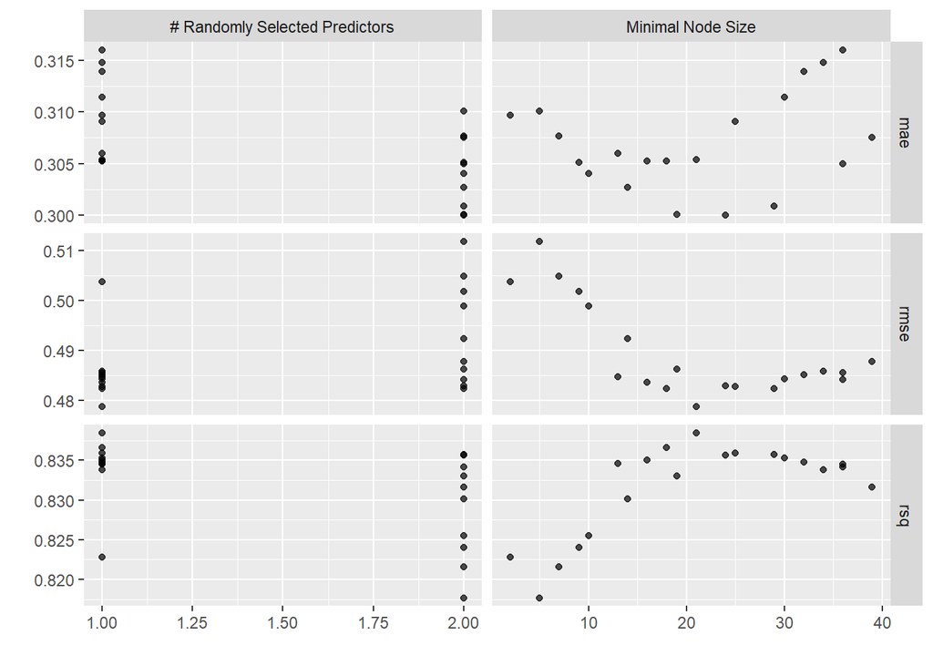

```r
dials <- extract_parameter_set_dials(rf_tune_workflow)

dials <- dials %>%
  finalize(select(camels_train, aridity, elev_mean))


#defined search space
my.grid <- grid_latin_hypercube(dials, size = 20)
#Executed tune grid
model_params <- tune_grid(
  rf_tune_workflow,
  resamples = folds,
  grid = my.grid,
  metrics = metric_set(rmse, rsq, mae),
  control = control_grid(save_pred = TRUE))

autoplot(model_params)
```

#### Dial ranges

I am tuning “mtry” to limit the model complexity through limts on the number of predictors implemented at each split of my rf model. I am also fitting the “min_n” which allows me to minimize the number of observations at each node. Ultimately both of these hyperparameters can limit the risk of overfitting with my model.

## Check the skill of tuned model

```r
#collect_metrics, Showbest, describe in plain language the interpretation of these

collect_metrics(model_params) %>%
  arrange(.metric == "mae")
```

```
# A tibble: 60 × 8
    mtry min_n .metric .estimator  mean     n std_err .config
   <int> <int> <chr>   <chr>      <dbl> <int>   <dbl> <chr>
 1     1    13 rmse    standard   0.485    10  0.0331 Preprocessor1_Model01
 2     1    13 rsq     standard   0.835    10  0.0165 Preprocessor1_Model01
 3     1    36 rmse    standard   0.486    10  0.0336 Preprocessor1_Model02
 4     1    36 rsq     standard   0.835    10  0.0159 Preprocessor1_Model02
 5     1    30 rmse    standard   0.484    10  0.0339 Preprocessor1_Model03
 6     1    30 rsq     standard   0.835    10  0.0161 Preprocessor1_Model03
 7     1    18 rmse    standard   0.482    10  0.0337 Preprocessor1_Model04
 8     1    18 rsq     standard   0.837    10  0.0166 Preprocessor1_Model04
 9     1    21 rmse    standard   0.479    10  0.0336 Preprocessor1_Model05
10     1    21 rsq     standard   0.838    10  0.0161 Preprocessor1_Model05
# ℹ 50 more rows
```

```r
show_best(model_params, metric = "mae")
```

```
# A tibble: 5 × 8
   mtry min_n .metric .estimator  mean     n std_err .config
  <int> <int> <chr>   <chr>      <dbl> <int>   <dbl> <chr>
1     2    24 mae     standard   0.300    10  0.0174 Preprocessor1_Model12
2     2    19 mae     standard   0.300    10  0.0177 Preprocessor1_Model20
3     2    29 mae     standard   0.301    10  0.0171 Preprocessor1_Model19
4     2    14 mae     standard   0.303    10  0.0181 Preprocessor1_Model14
5     2    10 mae     standard   0.304    10  0.0181 Preprocessor1_Model07
```

```r
hp_best <- select_best(model_params, metric = "mae")
```

## Finalize model

```r
#Finalize workflow
final_rf_workflow <- finalize_workflow(rf_tune_workflow, hp_best)
```

## Final model verification

```r
# Implement the last fit
final_fit <- last_fit(final_rf_workflow, split = camels_split)

#Interpret metrics
collect_metrics(final_fit)
```

```
# A tibble: 2 × 4
  .metric .estimator .estimate .config
  <chr>   <chr>          <dbl> <chr>
1 rmse    standard       0.410 Preprocessor1_Model1
2 rsq     standard       0.873 Preprocessor1_Model1
```

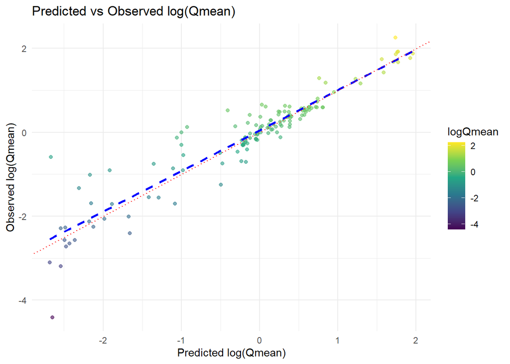

```r
#plot predictions
final_fit %>%
  collect_predictions() %>%
  ggplot(aes(x = .pred, y = logQmean)) +
  geom_point(aes(color = logQmean), alpha = 0.6) +
  geom_smooth(method = "lm", se = FALSE, color = "blue", linetype = "dashed") +
  geom_abline(slope = 1, intercept = 0, color = "red", linetype = "dotted") +
  scale_color_viridis_c() +
  labs(title = "Predicted vs Observed log(Qmean)",
       x = "Predicted log(Qmean)", y = "Observed log(Qmean)") +
  theme_minimal()
```

## Final Figure

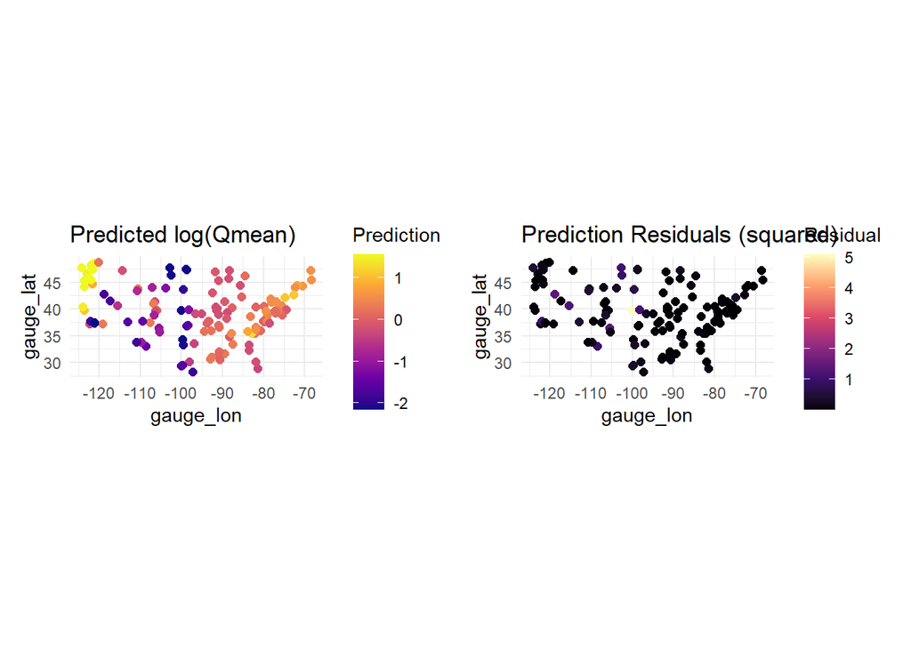

```r
#Augment Data and Calculate residuals
final_model_full <- fit(final_rf_workflow, data = camels_test)
camels_predicted <- augment(final_model_full, new_data = camels_test) %>%
  mutate(residual = (logQmean - .pred)^2)

#Map Predicted Q and Residuals
library(patchwork)

pred_map <- ggplot(camels_predicted, aes(x = gauge_lon, y = gauge_lat, color = .pred)) +
  geom_point(size = 2) +
  scale_color_viridis_c(option = "C") +
  coord_fixed(1.3) +
  labs(title = "Predicted log(Qmean)", color = "Prediction") +
  theme_minimal()

resid_map <- ggplot(camels_predicted, aes(x = gauge_lon, y = gauge_lat, color = residual)) +
  geom_point(size = 2) +
  scale_color_viridis_c(option = "A") +
  coord_fixed(1.3) +
  labs(title = "Prediction Residuals (squared)", color = "Residual") +
  theme_minimal()

pred_map + resid_map
```

## Results/Discussion

These ranges represent the search space during my hyperparameter tuning that helped me optimize my model performance.

The plot of predicted vs. actual streamflow values shows a pretty strong positive linear relationship, with most points clustered reasonably close to the 1:1 line. Basically the model captures the overall trend in the data, but it is not perfect and could certainly be improved at lower values of log q mean.